# HDAT9600 Final Team Assignment

Team 6 (Nick Duce, Ruochen Han, Yaru Ding, Kathleen Irena)

16/08/2022

## Instructions

- This file (hdat9600assess4_teamX.Rmd) is the R Markdown document in which you need to complete your HDAT9600 final team assignment.
- You should rename the file by replacing ‘X’ with your team number.
- This assignment is assessed and will count for 30% of the total course marks.
- The assignment comprises two tasks. The first task will focus on logistic regression, and the second task will focus on survival analysis.
- There is no word limit, nor limit on the length of your submitted Rmarkdown (i.e. this file) document.
- The **rendered** html document, were it to be printed, should be **no more** than about 10 A4 pages in length.
- Your html rendered document should include sufficient code chunks, output, and visual display as necessary to support your discursive commentary addressing each task. You may therefore wish to **suppress some of the contents** of your Rmarkdown file from appearing within the rendered document.
- The rendered (html) document will be the submission primarily considered when awarding credit. However, the Rmarkdown file may also be considered as deemed appropriate.
- **Excessively long reports will be penalised** by cessation of awarding of credit after roughly 10 pages of content.
- All tasks are intended to be completed as a team. Have fun discussing the tasks and working together.

Don’t hesitate to ask the course convenor for help via OpenLearning. The course instructor are happy to point you in the right direction and to make suggestions, but they won’t, of course, complete your assessment for you!

## Data for this assessment

The data used for this assessment consist of records from Intensive Care Unit (ICU) hospital stays in the USA. All patients were adults who were admitted for a wide variety of reasons. ICU stays of less than 48 hours have been excluded. The source data for the assessment are data made freely available for the 2012 MIT PhysioNet/Computing for Cardiology Challenge. Details are provided [here](https://physionet.org/challenge/2012/). Training Set A data have been used. The original data has been modified and assembled to suit the purpose of this assessment. While not required for the purposes of this assignment, full details of the preparatory work can be found in the ‘hdat9600assess4_final_data_prep’ file. The dataframe consists of 120 variables, which are defined as follows:

#### Patient Descriptor Variables

*RecordID:* a unique integer for each ICU stay

*Age:* years

*Gender:* male/female

*Height:* cm

*ICUType:* Coronary Care Unit; Cardiac Surgery Recovery Unit; Medical ICU; Surgical ICU

*Length_of_stay:* The number of days between the patient’s admission to the ICU and the end of hospitalisation

*Survival:* The number of days between ICU admission and death for patients who died

#### Outcome Variables

*in_hospital_death:* 0:survivor/1:died in-hospital **this is the outcome variable for Task 1: Logistic Regression**

*Status:* True/False **this is the censoring variable for Task 2: Survival Analysis**

*Days:* Length of survival (in days) **this is the survival time variable for Task 2: Survival Analysis**

#### Clinical Variables

*Use the hyperlinks below to find out more about the clinical meaning of each variable.* The first two clinical variables are summary scores that are used to assess patient condition and risk.

- SAPS-I score - Simplified Acute Physiological Score [Le Gall et al., 1984](http://www.ncbi.nlm.nih.gov/pubmed/6499483)
- SOFA score - Sequential Organ Failure Assessment [Ferreira et al., 2001](http://www.ncbi.nlm.nih.gov/pubmed/11594901)

The following 36 clinical measures were assessed at multiple timepoints during each patient’s ICU stay. For each of the 36 clinical measures, you are given 3 summary variables: a) The minimum value during the first 24 hours in ICU (_min), b) The maximum value during the first 24 hours in ICU (_max), and c) The difference between the mean and the most extreme values during the first 24 hours in ICU (_diff). For example, for the clinical measure Cholesterol, these three variables are labelled ‘Cholesterol_min’, ‘Cholesterol_max’, and ‘Cholesterol_diff’.

- [Albumin](http://en.wikipedia.org/wiki/Human_serum_albumin) (g/dL)
- [ALP](http://en.wikipedia.org/wiki/Alkaline_phosphatase) [Alkaline phosphatase (IU/L)]
- [ALT](http://en.wikipedia.org/wiki/Alanine_transaminase) [Alanine transaminase (IU/L)]
- [AST](http://en.wikipedia.org/wiki/Aspartate_transaminase) [Aspartate transaminase (IU/L)]
- Bilirubin (mg/dL)
- BUN [Blood urea nitrogen (mg/dL)]
- Cholesterol (mg/dL)
- [Creatinine](http://en.wikipedia.org/wiki/Serum_creatinine#Plasma_creatinine) [Serum creatinine (mg/dL)]
- [DiasABP](http://en.wikipedia.org/wiki/Diastolic_blood_pressure) [Invasive diastolic arterial blood pressure (mmHg)]
- [FiO2](http://en.wikipedia.org/wiki/FIO2) [Fractional inspired O<sub>2</sub> (0-1)]
- [GCS](http://en.wikipedia.org/wiki/Glasgow_coma_score) [Glasgow Coma Score (3-15)]
- [Glucose](http://en.wikipedia.org/wiki/Serum_glucose) [Serum glucose (mg/dL)]
- [HCO3](http://en.wikipedia.org/wiki/Bicarbonate#Diagnostics) [Serum bicarbonate (mmol/L)]
- [HCT](http://en.wikipedia.org/wiki/Hematocrit) [Hematocrit (%)]
- [HR](http://en.wikipedia.org/wiki/Heart_rate) [Heart rate (bpm)]
- [K](http://en.wikipedia.org/wiki/Hypokalemia) [Serum potassium (mEq/L)]
- [Lactate](http://en.wikipedia.org/wiki/Lactic_acid) (mmol/L)
- [Mg](http://en.wikipedia.org/wiki/Magnesium#Biological_role) [Serum magnesium (mmol/L)]
- [MAP](http://en.wikipedia.org/wiki/Mean_arterial_pressure) [Invasive mean arterial blood pressure (mmHg)]
- [MechVent](http://en.wikipedia.org/wiki/Mechanical_ventilation) [Mechanical ventilation respiration (0:false, or 1:true)]
- [Na](http://en.wikipedia.org/wiki/Serum_sodium) [Serum sodium (mEq/L)]
- [NIDiasABP](http://en.wikipedia.org/wiki/Diastolic_blood_pressure) [Non-invasive diastolic arterial blood pressure (mmHg)]
- [NIMAP](http://en.wikipedia.org/wiki/Mean_arterial_pressure) [Non-invasive mean arterial blood pressure (mmHg)]
- [NISysABP](http://en.wikipedia.org/wiki/Systolic_blood_pressure) [Non-invasive systolic arterial blood pressure (mmHg)]
- [PaCO2](http://en.wikipedia.org/wiki/Arterial_blood_gas) [partial pressure of arterial CO<sub>2</sub> (mmHg)]
- [PaO2](http://en.wikipedia.org/wiki/Arterial_blood_gas) [Partial pressure of arterial O<sub>2</sub> (mmHg)]
- [pH](http://en.wikipedia.org/wiki/Arterial_blood_gas) [Arterial pH (0-14)]
- Platelets (cells/nL)
- [RespRate](http://en.wikipedia.org/wiki/Respiratory_physiology) [Respiration rate (bpm)]
- [SaO2](http://en.wikipedia.org/wiki/Arterial_blood_gas) [O<sub>2</sub> saturation in hemoglobin (%)]
- [SysABP](http://en.wikipedia.org/wiki/Systolic_blood_pressure) [Invasive systolic arterial blood pressure (mmHg)]
- [Temp](http://en.wikipedia.org/wiki/Normal_human_body_temperature) [Temperature (°C)]
- [TropI](http://en.wikipedia.org/wiki/Troponin) [Troponin-I (μg/L)]
- [TropT](http://en.wikipedia.org/wiki/Troponin) [Troponin-T (μg/L)]
- [Urine](http://en.wikipedia.org/wiki/Fluid_balance) [Urine output (mL)]
- [WBC](http://en.wikipedia.org/wiki/Reference_ranges_for_blood_tests#Hematology) [White blood cell count (cells/nL)]
- Weight (kg)

## Accessing the Data

The data frame can be loaded with the following code:

```
icu_patients_df0 <- readRDS("icu_patients_df0.rds")
icu_patients_df1 <- readRDS("icu_patients_df1.rds")
```

**Note:** icu_patients_df1 is an imputed (i.e. missing values are ‘derived’) version of icu_patients_df0. This assessment does not concern the methods used for imputation.

# Task 1

In this task we construct a logistic regression model to find variables in the ICU dataset that predict in-hospital mortality. We performed exploratory data analysis and have included graphs of our descriptive statistics. We then performed significance testing of between surivors and non-survivors to identify variables of interest. Our approach to formulating our model was to initially create a model using all predictors from the dataset and then use step-wise exclusion of non-significant predictors to formulate our final model. We then assessed the model’s goodness-of-fit using a receiver-operator characteristic curve and performed model diagnostics to assess whether our model violated any assumptions of generalised linear models.

## Demographics

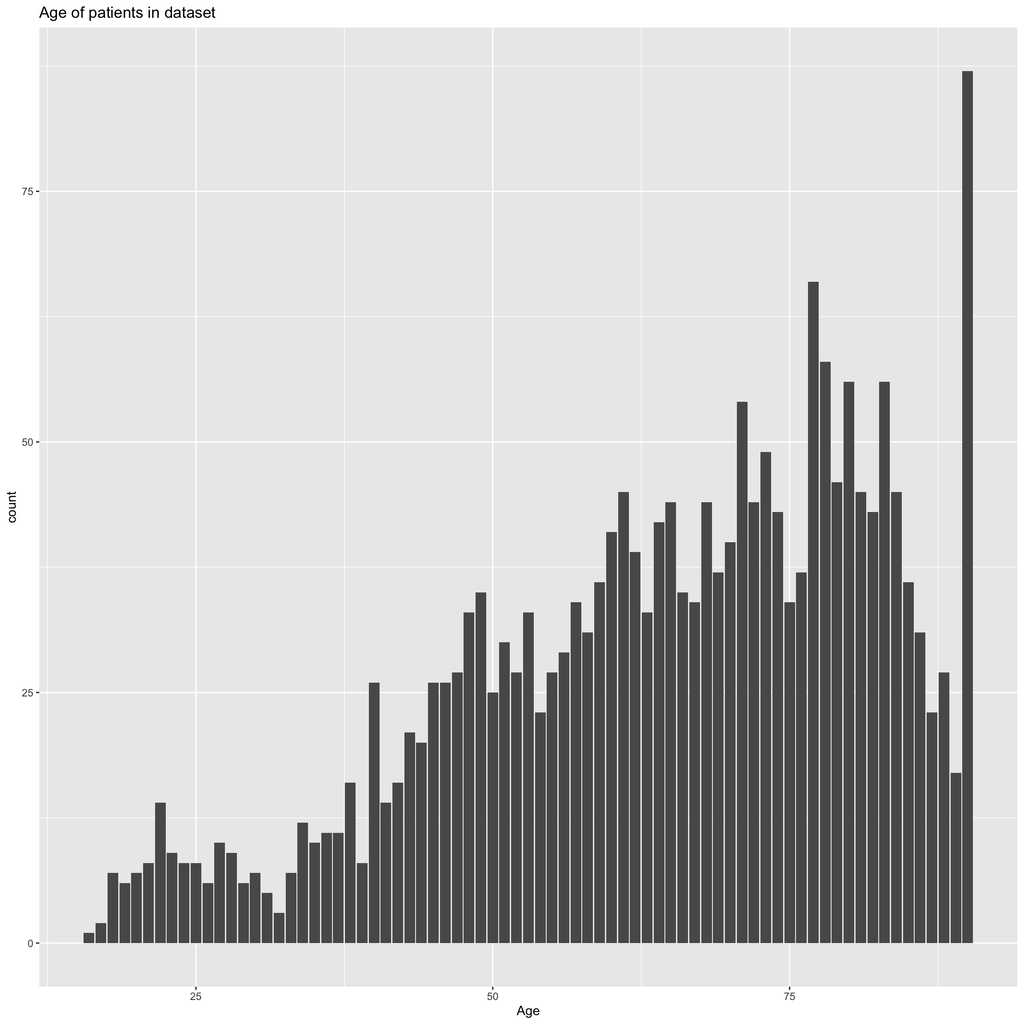

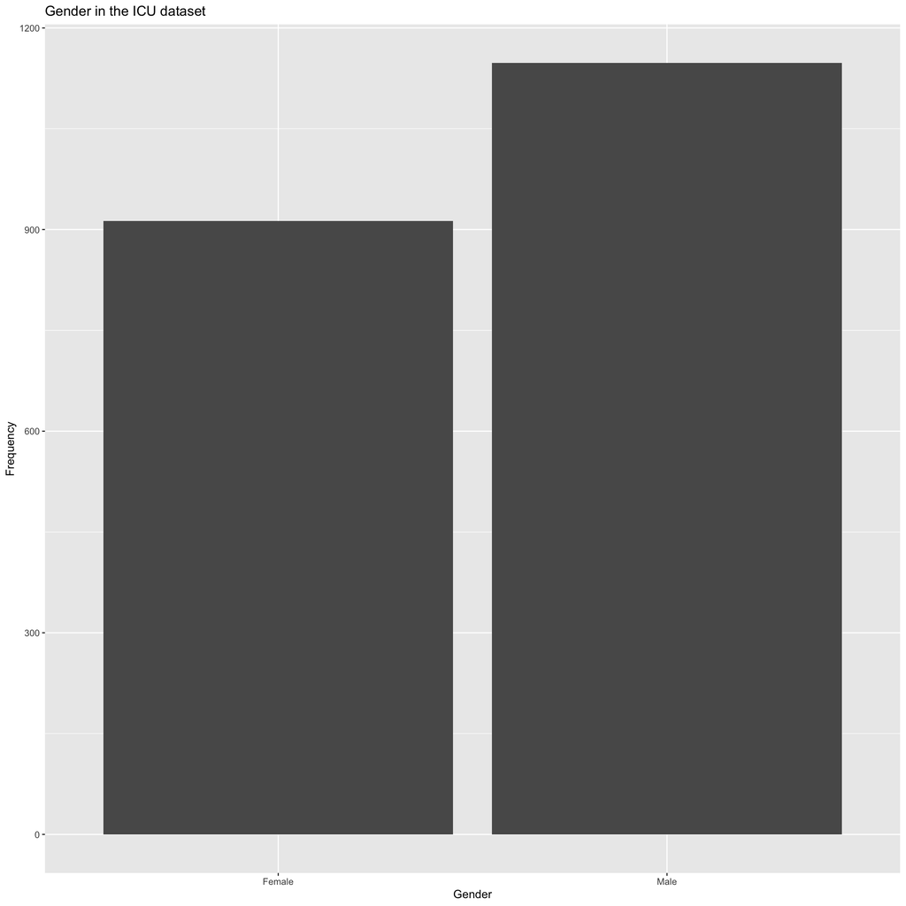

```r
icu_removed_na$hospital_death <- factor(icu_removed_na$in_hospital_death, labels=c("Survivor","in_hospital_death"))
```

## Fitting multivariate logistic regression models

After examining the dataset, we formulate model 1 using all possible predictor variables (output not included for brevity).

All significant predictors are included in model 2. ICU type is non-significant in model 2 so is excluded from model 3.

```r
mod3 <- glm(in_hospital_death ~ SAPS1 + Age + AST_max + Bilirubin_min + BUN_min + Cholesterol_max + Cholesterol_min + GCS_max + Platelets_diff + Platelets_max, family = binomial(link = 'logit'), data=icu_removed_na)
summary(mod3)
```

```
##
## Call:
## glm(formula = in_hospital_death ~ SAPS1 + Age + AST_max + Bilirubin_min +
##     BUN_min + Cholesterol_max + Cholesterol_min + GCS_max + Platelets_diff +
##     Platelets_max, family = binomial(link = "logit"), data = icu_removed_na)
##
## Deviance Residuals:
##     Min       1Q   Median       3Q      Max
## -1.8557  -0.5333  -0.3773  -0.2213   2.8761
##
## Coefficients:
##                   Estimate Std. Error z value Pr(>|z|)
## (Intercept)     -3.240e+00  7.137e-01  -4.539 5.65e-06 ***
## SAPS1            4.166e-02  1.714e-02   2.431  0.01506 *
## Age              3.522e-02  5.518e-03   6.382 1.75e-10 ***
## AST_max          2.581e-04  8.344e-05   3.093  0.00198 **
## Bilirubin_min    8.424e-02  2.043e-02   4.124 3.72e-05 ***
## BUN_min          2.540e-02  3.282e-03   7.739 1.00e-14 ***
## Cholesterol_max  1.588e-02  7.145e-03   2.223  0.02622 *
## Cholesterol_min -1.752e-02  7.036e-03  -2.491  0.01275 *
## GCS_max         -1.673e-01  2.371e-02  -7.053 1.75e-12 ***
## Platelets_diff   3.880e-03  1.244e-03   3.119  0.00182 **
## Platelets_max   -2.782e-03  8.895e-04  -3.128  0.00176 **
## ---
## Signif. codes:  0 '***' 0.001 '**' 0.01 '*' 0.05 '.' 0.1 ' ' 1
##
## (Dispersion parameter for binomial family taken to be 1)
##
##     Null deviance: 1524.4  on 1818  degrees of freedom
## Residual deviance: 1238.2  on 1808  degrees of freedom
## AIC: 1260.2
##
## Number of Fisher Scoring iterations: 5
```

We then compare mod2 to mod3 using an analysis of deviance. mod2 has the lowest AIC at 1224.3 so we choose mod2 as our final model.

```r
# anova test to test which model is better
anova(mod2, mod3,test='Chisq')
```

```
## Analysis of Deviance Table
##
## Model 1: in_hospital_death ~ SAPS1 + Age + AST_max + Bilirubin_min + BUN_min +
##     Cholesterol_max + Cholesterol_min + GCS_max + ICUType + pH_diff +
##     Platelets_diff + Platelets_max
## Model 2: in_hospital_death ~ SAPS1 + Age + AST_max + Bilirubin_min + BUN_min +
##     Cholesterol_max + Cholesterol_min + GCS_max + Platelets_diff +
##     Platelets_max
##   Resid. Df Resid. Dev Df Deviance  Pr(>Chi)
## 1      1804     1194.3
## 2      1808     1238.2 -4   -43.84 6.926e-09 ***
## ---
## Signif. codes:  0 '***' 0.001 '**' 0.01 '*' 0.05 '.' 0.1 ' ' 1
```

## Goodness-of-fit and model diagnostics

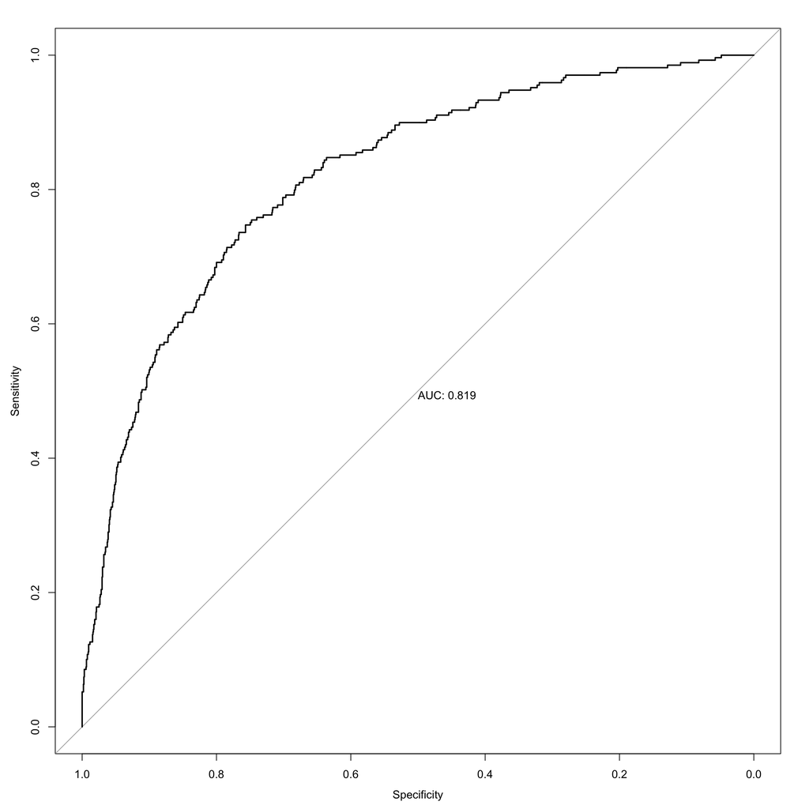

```r
# testing goodness of fit with a ROC curve
# create predicted values
icu_removed_na %>% mutate(predprob=predict(mod2, type="response")) -> icu_pred_mod2

# rOC curve and AUC of precicted values for full model
test_roc_mod2 = roc(icu_pred_mod2$in_hospital_death ~ icu_pred_mod2$predprob, plot = TRUE, print.auc = TRUE)
```

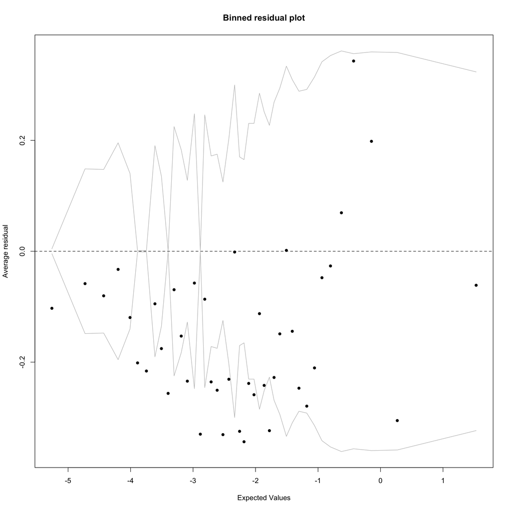

```r
# model diagnostics
binnedplot(predict(mod2), residuals(mod2))
```

We found an AUC of 0.819, which shows that our model has fairly good goodness of fit our dataset.We do find that we have quite a few values falling outside the 95% confidence interval bounds on our binned residual plot. This tells us that the residuals may not be normally distributed (and appear to have a negative proponderence) and as such violate the assumption of normality for residuals.

```r
icu_patients_df0 <- readRDS("icu_patients_df0.rds")
icu_removed_na2 <- icu_patients_df0[colSums(is.na(icu_patients_df0))/nrow(icu_patients_df0) < .2]
icu_removed_na2 <- na.omit(icu_removed_na2)

icu_removed_na2$SOFA[icu_removed_na2$SOFA == -1] <- NA
icu_removed_na2$Length_of_stay[icu_removed_na2$Length_of_stay == -1] <- NA
icu_removed_na2 <- na.omit(icu_removed_na2)

mod4 <- glm(in_hospital_death ~ SAPS1 + Age + BUN_min  + GCS_max + ICUType + Platelets_diff + Platelets_max, family = binomial(link = 'logit'), data=icu_removed_na2)
summary(mod4)
```

```
##
## Call:
## glm(formula = in_hospital_death ~ SAPS1 + Age + BUN_min + GCS_max +
##     ICUType + Platelets_diff + Platelets_max, family = binomial(link = "logit"),
##     data = icu_removed_na2)
##
## Deviance Residuals:
##     Min       1Q   Median       3Q      Max
## -1.8650  -0.5549  -0.3748  -0.2112   2.9851
##
## Coefficients:
##                                       Estimate Std. Error z value Pr(>|z|)
## (Intercept)                          -3.137935   0.591390  -5.306 1.12e-07 ***
## SAPS1                                 0.092573   0.017874   5.179 2.23e-07 ***
## Age                                   0.025891   0.005131   5.046 4.52e-07 ***
## BUN_min                               0.020215   0.003372   5.995 2.03e-09 ***
## GCS_max                              -0.136129   0.024254  -5.613 1.99e-08 ***
## ICUTypeCardiac Surgery Recovery Unit -1.403039   0.313201  -4.480 7.48e-06 ***
## ICUTypeMedical ICU                   -0.122663   0.216354  -0.567  0.57074
## ICUTypeSurgical ICU                  -0.267108   0.237646  -1.124  0.26102
## Platelets_diff                        0.004651   0.001232   3.776  0.00016 ***
## Platelets_max                        -0.004033   0.000875  -4.609 4.05e-06 ***
## ---
## Signif. codes:  0 '***' 0.001 '**' 0.01 '*' 0.05 '.' 0.1 ' ' 1
##
## (Dispersion parameter for binomial family taken to be 1)
##
##     Null deviance: 1467.4  on 1728  degrees of freedom
## Residual deviance: 1194.1  on 1719  degrees of freedom
## AIC: 1214.1
##
## Number of Fisher Scoring iterations: 5
```

When we fit our model to the unimputed dataset, we find that we cannot use some variables as they have large proportions of missing data. This leaves our mdoel with SAPS1, Age, BUN_min, ICUType and platelets_diff and maximum as predictors.

# Task 2

In this task, we performed exploratory data analysis of sex and ICU type differences using non-parametric Kaplan-Meier estimations of survival. We then created univariate Cox proportional hazards models for all variables in the ICU dataset. From this, we created a multivariate Cox porportional hazards model using all significant univariate predictors, model 1. We again selected out significant predictors from model 1 to create model 2. Model 3 is a multivariate Cox PH model using all variables as predictors and model 4 uses only significant predictors from model 3. We then compare models 2, 3 and 4 and selected model 2 as our final model as it had the lowest Akaike Information Criterion (AIC). We then tested the proportional hazards assumption of our model and finally refit model 2 to the unimputed dataset.

## Exploratory data anlysis of gender and ICU type on survival

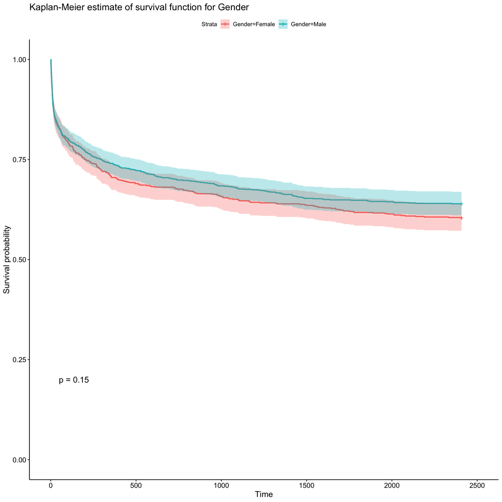

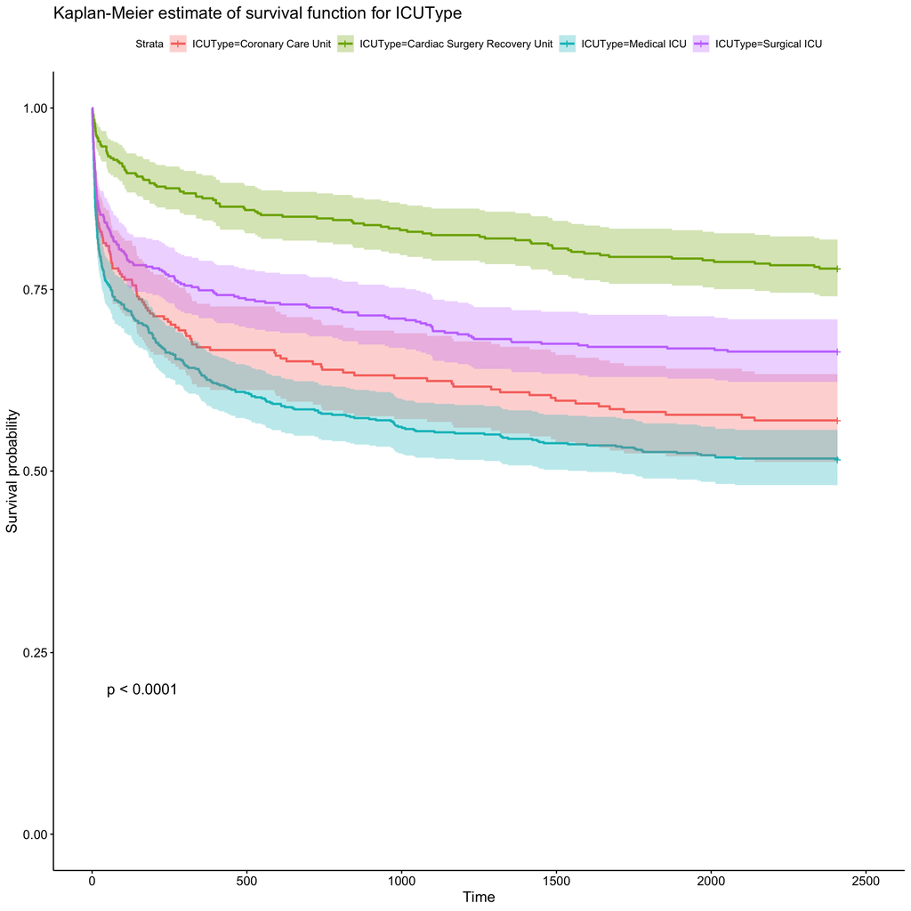

## Formulating univariate models

We formulated univariate models of all predictor variables (output suppressed for brevity). Significant predictors were included in our multivariate model 1.

```r
# fitting the univariate Cox proportional hazards models for "icu_removed_na"
covariates <- c("Length_of_stay", "SAPS1", "SOFA", "Age", "Albumin_diff", "Albumin_max", "Albumin_min", "ALP_diff", "ALP_max", "ALP_min", "ALT_diff",
"ALT_max", "ALT_min", "AST_diff", "AST_max", "AST_min", "Bilirubin_diff", "Bilirubin_max", "Bilirubin_min", "BUN_diff", "BUN_max", "BUN_min", "Cholesterol_diff", "Cholesterol_max", "Cholesterol_min", "Creatinine_diff", "Creatinine_max", "Creatinine_min", "FiO2_diff", "FiO2_max", "FiO2_min", "GCS_diff", "GCS_max", "GCS_min", "Gender", "Glucose_diff", "Glucose_max", "Glucose_min", "HCO3_diff", "HCO3_max", "HCO3_min", "HCT_diff", "HCT_max", "HCT_min", "HR_diff", "HR_max", "HR_min", "ICUType", "K_diff", "K_max", "K_min", "Lactate_diff", "Lactate_max", "Lactate_min", "MAP_diff", "MAP_max", "MAP_min", "Mg_diff", "Mg_max", "Mg_min", "Na_diff", "Na_max", "Na_min", "PaCO2_diff", "PaCO2_max", "PaCO2_min",
"PaO2_diff", "PaO2_max", "PaO2_min", "pH_diff", "pH_max", "pH_min", "Platelets_diff", "Platelets_max", "Platelets_min", "RespRate_diff", "RespRate_max", "RespRate_min", "SaO2_diff", "SaO2_max", "SaO2_min", "Temp_diff", "Temp_max", "Temp_min", "TroponinI_diff", "TroponinI_max", "TroponinI_min", "TroponinT_diff", "TroponinT_max", "TroponinT_min", "Urine_diff", "Urine_max", "Urine_min", "WBC_diff", "WBC_max", "WBC_min", "Weight_diff", "Weight_max","Weight_min")

univ_formulas <- sapply(covariates,
                        function(x) as.formula(paste('Surv(Days, Status)~', x)))

univ_models <- lapply( univ_formulas, function(x){coxph(x, data = icu_removed_na)})
univ_results <- lapply(univ_models,
                       function(x){
                          x <- summary(x)
                          p.value<-signif(x$wald["pvalue"], digits=2)
                          wald.test<-signif(x$wald["test"], digits=2)
                          beta<-signif(x$coef[1], digits=2);#coeficient beta
                          HR <-signif(x$coef[2], digits=2);#exp(beta)
                          HR.confint.lower <- signif(x$conf.int[,"lower .95"], 2)
                          HR.confint.upper <- signif(x$conf.int[,"upper .95"],2)
                          HR <- paste0(HR, " (",
                                       HR.confint.lower, "-", HR.confint.upper, ")")
                          res<-c(beta, HR, wald.test, p.value)
                          names(res)<-c("beta", "HR (95% CI for HR)", "wald.test",
                                        "p.value")
                          return(res)
                          return(exp(cbind(coef(x),confint(x))))
                         })
print(univ_results) # extract data
```

## Fitting multivariate models

Model 1 is a multivariate Cox PH model formulated using all significant univariate predictors. We then drop non-significant predictors from model 1 to create model 2. The summary of model 2 is shown below.

```r
cox.mv2 <- coxph(Surv(Days, Status) ~ SAPS1 + Age + Bilirubin_diff + Bilirubin_min + BUN_min + GCS_max + HCT_diff + Lactate_diff + PaO2_max + Weight_max, data = icu_removed_na)
summary(cox.mv2)
```

```
## Call:
## coxph(formula = Surv(Days, Status) ~ SAPS1 + Age + Bilirubin_diff +
##     Bilirubin_min + BUN_min + GCS_max + HCT_diff + Lactate_diff +
##     PaO2_max + Weight_max, data = icu_removed_na)
##
##   n= 1819, number of events= 684
##
##                      coef  exp(coef)   se(coef)      z Pr(>|z|)
## SAPS1           0.0415478  1.0424230  0.0094215  4.410 1.03e-05 ***
## Age             0.0276923  1.0280793  0.0028960  9.562  < 2e-16 ***
## Bilirubin_diff -0.0986596  0.9060511  0.0393899 -2.505  0.01226 *
## Bilirubin_min   0.1168183  1.1239151  0.0381036  3.066  0.00217 **
## BUN_min         0.0151890  1.0153049  0.0016090  9.440  < 2e-16 ***
## GCS_max        -0.0860330  0.9175640  0.0130078 -6.614 3.74e-11 ***
## HCT_diff       -0.0338016  0.9667633  0.0113834 -2.969  0.00298 **
## Lactate_diff    0.1156444  1.1225966  0.0210669  5.489 4.03e-08 ***
## PaO2_max       -0.0025664  0.9974369  0.0003801 -6.751 1.47e-11 ***
## Weight_max     -0.0056588  0.9943572  0.0019084 -2.965  0.00302 **
## ---
## Signif. codes:  0 '***' 0.001 '**' 0.01 '*' 0.05 '.' 0.1 ' ' 1
##
##                exp(coef) exp(-coef) lower .95 upper .95
## SAPS1             1.0424     0.9593    1.0234    1.0619
## Age               1.0281     0.9727    1.0223    1.0339
## Bilirubin_diff    0.9061     1.1037    0.8387    0.9788
## Bilirubin_min     1.1239     0.8897    1.0430    1.2111
## BUN_min           1.0153     0.9849    1.0121    1.0185
## GCS_max           0.9176     1.0898    0.8945    0.9413
## HCT_diff          0.9668     1.0344    0.9454    0.9886
## Lactate_diff      1.1226     0.8908    1.0772    1.1699
## PaO2_max          0.9974     1.0026    0.9967    0.9982
## Weight_max        0.9944     1.0057    0.9906    0.9981
##
## Concordance= 0.732  (se = 0.009 )
## Likelihood ratio test= 472.6  on 10 df,   p=<2e-16
## Wald test            = 478.3  on 10 df,   p=<2e-16
## Score (logrank) test = 501.8  on 10 df,   p=<2e-16
```

We then create model 3 which uses all variables as predictors and model 4 uses only the significant predictors from model 3.

```
## Analysis of Deviance Table
##  Cox model: response is  Surv(Days, Status)
##  Model 1: ~ SAPS1 + Age + Bilirubin_diff + Bilirubin_min + BUN_min + GCS_max + HCT_diff + Lactate_diff + PaO2_max + Weight_max
##  Model 2: ~ Gender + SAPS1 + SOFA + Age + ICUType + Lactate_diff + Bilirubin_diff + GCS_min + HR_min + Mg_max + Platelets_max + Platelets_min + Weight_max + WBC_diff + Weight_diff
##    loglik  Chisq Df P(>|Chi|)
## 1 -4749.4
## 2 -4743.9 10.991  7     0.139
```

```
## [1]   10.000 9518.802
```

```
## [1]   17.000 9521.811
```

## Model diagnostics

We tested the proportional hazard assumption for our final model (model 2).

```r
(prop.mvsig <- cox.zph(cox.mv2))
```

```
##                 chisq df       p
## SAPS1          15.419  1 8.6e-05
## Age             1.065  1  0.3020
## Bilirubin_diff  7.377  1  0.0066
## Bilirubin_min   8.537  1  0.0035
## BUN_min         1.993  1  0.1581
## GCS_max        21.698  1 3.2e-06
## HCT_diff        6.095  1  0.0136
## Lactate_diff    9.217  1  0.0024
## PaO2_max        0.138  1  0.7106
## Weight_max      0.647  1  0.4211
## GLOBAL         46.565 10 1.1e-06
```

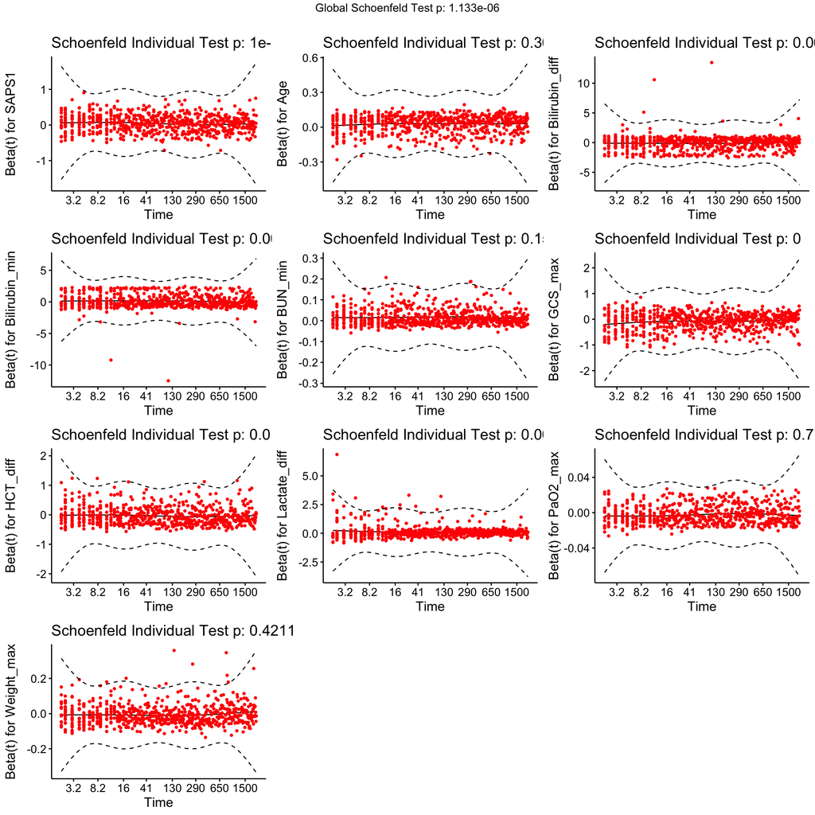

```r
ggcoxzph(prop.mvsig)
```

## Re-fitting model 2 to the unimputed dataset

Here, we refit model 2 to the unimputed dataset.

```r
cox.mvfinal <- coxph(Surv(Days, Status) ~ SAPS1 + Age + BUN_min + GCS_max + HCT_diff + Weight_max, data = icu_final)
summary(cox.mvfinal)
```

```
## Call:
## coxph(formula = Surv(Days, Status) ~ SAPS1 + Age + BUN_min +
##     GCS_max + HCT_diff + Weight_max, data = icu_final)
##
##   n= 873, number of events= 326
##
##                 coef exp(coef)  se(coef)      z Pr(>|z|)
## SAPS1       0.014824  1.014935  0.012459  1.190   0.2341
## Age         0.026067  1.026410  0.004603  5.663 1.48e-08 ***
## BUN_min     0.021526  1.021760  0.002118 10.164  < 2e-16 ***
## GCS_max    -0.113858  0.892385  0.017580 -6.477 9.39e-11 ***
## HCT_diff   -0.032290  0.968226  0.017557 -1.839   0.0659 .
## Weight_max -0.005015  0.994998  0.002807 -1.787   0.0740 .
## ---
## Signif. codes:  0 '***' 0.001 '**' 0.01 '*' 0.05 '.' 0.1 ' ' 1
##
##            exp(coef) exp(-coef) lower .95 upper .95
## SAPS1         1.0149     0.9853    0.9905    1.0400
## Age           1.0264     0.9743    1.0172    1.0357
## BUN_min       1.0218     0.9787    1.0175    1.0260
## GCS_max       0.8924     1.1206    0.8622    0.9237
## HCT_diff      0.9682     1.0328    0.9355    1.0021
## Weight_max    0.9950     1.0050    0.9895    1.0005
##
## Concordance= 0.714  (se = 0.014 )
## Likelihood ratio test= 189.5  on 6 df,   p=<2e-16
## Wald test            = 208.8  on 6 df,   p=<2e-16
## Score (logrank) test = 223.1  on 6 df,   p=<2e-16
```

Final model does not include Bilirubin, Lactate, and PaO2 variables due to the remaining available variables after data cleaning of icu_patients_df0. From the output we can see that the final model fits to “icu_final” and only three variables ‘Age’, ‘BUN_min’ and ‘GCS_max’ are significant. These three variables are definitely important in mortality prediction: a study has mentioned BUN can be used as an independent predictor of mortality in ICU patients [[Wernly et al., 2018](https://pubmed.ncbi.nlm.nih.gov/29758935/)], the same finding is also applied for GCS [[Hassan & Liu, 2020](https://journals.lww.com/ccmjournal/Fulltext/2020/01001/747__PROSPECTIVE_EVALUATION_OF_EARLY_GLASGOW_COMA.710.aspx)], and there have been numerous evidence on how patient’s survival rate is correlated to to Age